Libraries

```r
library(data.table)
library(psych)
library(GPArotation)
library(corpcor)
library(EFAtools)
library(lavaan)
```

```r
library(lavaanPlot)
library(esemComp)
library(ggplot2)
```

Set working directory

```r
setwd('/media/hcs-sci-psy-narun/IBu/UK_BB/brainbody/cognition/folds/')
```

Upload train and test sets generated and scaled in Python

```r
base_path <- "/media/hcs-sci-psy-narun/IBu/UK_BB/brainbody/cognition/folds/fold_"
file_names <- c("cogscores_12T_i2_train_with_id_scaled_fold_", "cogscores_12T_i2_test_with_id_scaled_fold_")

for (i in 0:4) {
  assign(paste0("train_", i), read.csv(paste0(base_path, i, "/cogscores/", file_names[1], i, ".csv"), header = TRUE))
  assign(paste0("test_", i), read.csv(paste0(base_path, i, "/cogscores/", file_names[2], i, ".csv"), header = TRUE))
}
```

Remove ID column

```r
train_files <- list(train_0, train_1, train_2, train_3, train_4)
test_files <- list(test_0, test_1, test_2, test_3, test_4)

# Function to remove columns
remove_columns <- function(df) {
  df <- subset(df, select = -c(eid))
  return(df)
}

# Apply the function to each data frame in the lists
train_files <- lapply(train_files, remove_columns)
test_files <- lapply(test_files, remove_columns)

# Assign the modified data frames back to their original names
train_0 <- train_files[[1]]
train_1 <- train_files[[2]]
train_2 <- train_files[[3]]
train_3 <- train_files[[4]]
train_4 <- train_files[[5]]

test_0 <- test_files[[1]]
test_1 <- test_files[[2]]
test_2 <- test_files[[3]]
test_3 <- test_files[[4]]
test_4 <- test_files[[5]]
```

#Factorability Bartlett test

```r
# Train
cortest.bartlett(cor(train_0), n = nrow(data))
```

```
## $chisq
## [1] 184.2732
##
## $p.value
## [1] 4.063337e-13
##
## $df
## [1] 66
```

```r
cortest.bartlett(cor(train_1), n = nrow(data))
```

```
## $chisq
## [1] 184.5251
##
## $p.value
## [1] 3.739996e-13
##
## $df
## [1] 66
```

```r
cortest.bartlett(cor(train_2), n = nrow(data))
```

```
## $chisq
## [1] 184.1046
##
## $p.value
## [1] 4.295129e-13
##
## $df
## [1] 66
```

```r
cortest.bartlett(cor(train_3), n = nrow(data))
```

```
## $chisq
## [1] 183.7138
##
## $p.value
## [1] 4.883971e-13
##
## $df
## [1] 66
```

```r
cortest.bartlett(cor(train_4), n = nrow(data))
```

```
## $chisq
## [1] 181.8838
##
## $p.value
## [1] 8.897327e-13
##
## $df
## [1] 66
```

```r
#Test
cortest.bartlett(cor(test_0), n = nrow(data))
```

```
## $chisq
## [1] 182.2864
##
## $p.value
## [1] 7.799524e-13
##
## $df
## [1] 66
```

```r
cortest.bartlett(cor(test_1), n = nrow(data))
```

```
## $chisq
## [1] 181.1042
##
## $p.value
## [1] 1.147661e-12
##
## $df
## [1] 66
```

```r
cortest.bartlett(cor(test_2), n = nrow(data))
```

```
## $chisq
## [1] 182.8239
##
## $p.value
## [1] 6.540428e-13
##
## $df
## [1] 66
```

```r
cortest.bartlett(cor(test_3), n = nrow(data))
```

```
## $chisq
## [1] 184.6203
##
## $p.value
## [1] 3.62458e-13
##
## $df
## [1] 66
```

```r
cortest.bartlett(cor(test_4), n = nrow(data))
```

```
## $chisq
## [1] 191.7042
##
## $p.value
## [1] 3.437284e-14
##
## $df
## [1] 66
```

KMO test

```r
#Train
KMO(train_0)
```

```
## ℹ 'x' was not a correlation matrix. Correlations are found from entered raw data.
```

```
##
## ── Kaiser-Meyer-Olkin criterion (KMO) ──────────────────────────────────────────
##
## ✔ The overall KMO value for your data is meritorious.
##   These data are probably suitable for factor analysis.
##
##   Overall: 0.86
##
##   For each variable:
##      Numeric.memory..Maximum.digits.remembered.correctly
##                                                    0.895
##                       Prospective.memory..Initial.answer
##                                                    0.913
##     Matrix.pattern.completion..Number.of.puzzles.correct
##                                                    0.899
##                                 Fluid.intelligence.score
##                                                    0.827
##                             PAL..Number.of.correct.pairs
##                                                    0.904
##             Tower.rearranging..Number.of.puzzles.correct
##                                                    0.901
##           Picture.vocabulary..Specific.cognitive.ability
##                                                    0.737
## Symbol.digit.substitution..Proportion.of.correct.matches
##                                                    0.892
##             X.log.TMT..Duration.to.complete.numeric.path
##                                                    0.834
##          X.log.TMT..Duration.to.complete.alphabetic.path
##                                                    0.839
##                                      X.log.Reaction.time
##                                                    0.887
##               X.logx.1.Pairs.matching..Incorrect.matches
##                                                    0.903
```

```r
KMO(train_1)
```

```
## ℹ 'x' was not a correlation matrix. Correlations are found from entered raw data.
```

```
##
## ── Kaiser-Meyer-Olkin criterion (KMO) ──────────────────────────────────────────
##
## ✔ The overall KMO value for your data is meritorious.
##   These data are probably suitable for factor analysis.
##
##   Overall: 0.861
##
##   For each variable:
##      Numeric.memory..Maximum.digits.remembered.correctly
##                                                    0.899
##                       Prospective.memory..Initial.answer
##                                                    0.914
##     Matrix.pattern.completion..Number.of.puzzles.correct
##                                                    0.898
##                                 Fluid.intelligence.score
##                                                    0.827
##                             PAL..Number.of.correct.pairs
##                                                    0.905
##             Tower.rearranging..Number.of.puzzles.correct
##                                                    0.900
##           Picture.vocabulary..Specific.cognitive.ability
##                                                    0.739
## Symbol.digit.substitution..Proportion.of.correct.matches
##                                                    0.890
##             X.log.TMT..Duration.to.complete.numeric.path
##                                                    0.836
##          X.log.TMT..Duration.to.complete.alphabetic.path
##                                                    0.840
##                                      X.log.Reaction.time
##                                                    0.892
##               X.logx.1.Pairs.matching..Incorrect.matches
##                                                    0.904
```

```r
KMO(train_2)
```

```
## ℹ 'x' was not a correlation matrix. Correlations are found from entered raw data.
```

```
##
## ── Kaiser-Meyer-Olkin criterion (KMO) ──────────────────────────────────────────
##
## ✔ The overall KMO value for your data is meritorious.
##   These data are probably suitable for factor analysis.
##
##   Overall: 0.859
##
##   For each variable:
##      Numeric.memory..Maximum.digits.remembered.correctly
##                                                    0.897
##                       Prospective.memory..Initial.answer
##                                                    0.914
##     Matrix.pattern.completion..Number.of.puzzles.correct
##                                                    0.897
##                                 Fluid.intelligence.score
##                                                    0.826
##                             PAL..Number.of.correct.pairs
##                                                    0.905
##             Tower.rearranging..Number.of.puzzles.correct
##                                                    0.899
##           Picture.vocabulary..Specific.cognitive.ability
##                                                    0.736
## Symbol.digit.substitution..Proportion.of.correct.matches
##                                                    0.895
##             X.log.TMT..Duration.to.complete.numeric.path
##                                                    0.834
##          X.log.TMT..Duration.to.complete.alphabetic.path
##                                                    0.837
##                                      X.log.Reaction.time
##                                                    0.889
##               X.logx.1.Pairs.matching..Incorrect.matches
##                                                    0.907
```

```r
KMO(train_3)
```

```
## ℹ 'x' was not a correlation matrix. Correlations are found from entered raw data.
```

```
##
## ── Kaiser-Meyer-Olkin criterion (KMO) ──────────────────────────────────────────
##
## ✔ The overall KMO value for your data is meritorious.
##   These data are probably suitable for factor analysis.
##
##   Overall: 0.86
##
##   For each variable:
##      Numeric.memory..Maximum.digits.remembered.correctly
##                                                    0.896
##                       Prospective.memory..Initial.answer
##                                                    0.913
##     Matrix.pattern.completion..Number.of.puzzles.correct
##                                                    0.898
##                                 Fluid.intelligence.score
##                                                    0.828
##                             PAL..Number.of.correct.pairs
##                                                    0.905
##             Tower.rearranging..Number.of.puzzles.correct
##                                                    0.898
##           Picture.vocabulary..Specific.cognitive.ability
##                                                    0.739
## Symbol.digit.substitution..Proportion.of.correct.matches
##                                                    0.899
##             X.log.TMT..Duration.to.complete.numeric.path
##                                                    0.838
##          X.log.TMT..Duration.to.complete.alphabetic.path
##                                                    0.839
##                                      X.log.Reaction.time
##                                                    0.891
##               X.logx.1.Pairs.matching..Incorrect.matches
##                                                    0.900
```

```r
KMO(train_4)
```

```
## ℹ 'x' was not a correlation matrix. Correlations are found from entered raw data.
```

```
##
## ── Kaiser-Meyer-Olkin criterion (KMO) ──────────────────────────────────────────
##
## ✔ The overall KMO value for your data is meritorious.
##   These data are probably suitable for factor analysis.
##
##   Overall: 0.858
##
##   For each variable:
##      Numeric.memory..Maximum.digits.remembered.correctly
##                                                    0.895
##                       Prospective.memory..Initial.answer
##                                                    0.912
##     Matrix.pattern.completion..Number.of.puzzles.correct
##                                                    0.896
##                                 Fluid.intelligence.score
##                                                    0.826
##                             PAL..Number.of.correct.pairs
##                                                    0.903
##             Tower.rearranging..Number.of.puzzles.correct
##                                                    0.898
##           Picture.vocabulary..Specific.cognitive.ability
##                                                    0.738
## Symbol.digit.substitution..Proportion.of.correct.matches
##                                                    0.891
##             X.log.TMT..Duration.to.complete.numeric.path
##                                                    0.831
##          X.log.TMT..Duration.to.complete.alphabetic.path
##                                                    0.836
##                                      X.log.Reaction.time
##                                                    0.887
##               X.logx.1.Pairs.matching..Incorrect.matches
##                                                    0.904
```

```r
#Test
KMO(test_0)
```

```
## ℹ 'x' was not a correlation matrix. Correlations are found from entered raw data.
```

```
##
## ── Kaiser-Meyer-Olkin criterion (KMO) ──────────────────────────────────────────
##
## ✔ The overall KMO value for your data is meritorious.
##   These data are probably suitable for factor analysis.
##
##   Overall: 0.858
##
##   For each variable:
##      Numeric.memory..Maximum.digits.remembered.correctly
##                                                    0.900
##                       Prospective.memory..Initial.answer
##                                                    0.910
##     Matrix.pattern.completion..Number.of.puzzles.correct
##                                                    0.893
##                                 Fluid.intelligence.score
##                                                    0.826
##                             PAL..Number.of.correct.pairs
##                                                    0.904
##             Tower.rearranging..Number.of.puzzles.correct
##                                                    0.889
##           Picture.vocabulary..Specific.cognitive.ability
##                                                    0.737
## Symbol.digit.substitution..Proportion.of.correct.matches
##                                                    0.894
##             X.log.TMT..Duration.to.complete.numeric.path
##                                                    0.836
##          X.log.TMT..Duration.to.complete.alphabetic.path
##                                                    0.837
##                                      X.log.Reaction.time
##                                                    0.898
##               X.logx.1.Pairs.matching..Incorrect.matches
##                                                    0.901
```

```r
KMO(test_1)
```

```
## ℹ 'x' was not a correlation matrix. Correlations are found from entered raw data.
```

```
##
## ── Kaiser-Meyer-Olkin criterion (KMO) ──────────────────────────────────────────
##
## ✔ The overall KMO value for your data is meritorious.
##   These data are probably suitable for factor analysis.
##
##   Overall: 0.854
##
##   For each variable:
##      Numeric.memory..Maximum.digits.remembered.correctly
##                                                    0.885
##                       Prospective.memory..Initial.answer
##                                                    0.910
##     Matrix.pattern.completion..Number.of.puzzles.correct
##                                                    0.895
##                                 Fluid.intelligence.score
##                                                    0.825
##                             PAL..Number.of.correct.pairs
##                                                    0.901
##             Tower.rearranging..Number.of.puzzles.correct
##                                                    0.894
##           Picture.vocabulary..Specific.cognitive.ability
##                                                    0.734
## Symbol.digit.substitution..Proportion.of.correct.matches
##                                                    0.903
##             X.log.TMT..Duration.to.complete.numeric.path
##                                                    0.831
##          X.log.TMT..Duration.to.complete.alphabetic.path
##                                                    0.829
##                                      X.log.Reaction.time
##                                                    0.874
##               X.logx.1.Pairs.matching..Incorrect.matches
##                                                    0.896
```

```r
KMO(test_2)
```

```
## ℹ 'x' was not a correlation matrix. Correlations are found from entered raw data.
```

```
##
## ── Kaiser-Meyer-Olkin criterion (KMO) ──────────────────────────────────────────
##
## ✔ The overall KMO value for your data is meritorious.
##   These data are probably suitable for factor analysis.
##
##   Overall: 0.86
##
##   For each variable:
##      Numeric.memory..Maximum.digits.remembered.correctly
##                                                    0.892
##                       Prospective.memory..Initial.answer
##                                                    0.909
##     Matrix.pattern.completion..Number.of.puzzles.correct
##                                                    0.900
##                                 Fluid.intelligence.score
##                                                    0.829
##                             PAL..Number.of.correct.pairs
##                                                    0.901
##             Tower.rearranging..Number.of.puzzles.correct
##                                                    0.900
##           Picture.vocabulary..Specific.cognitive.ability
##                                                    0.744
## Symbol.digit.substitution..Proportion.of.correct.matches
##                                                    0.875
##             X.log.TMT..Duration.to.complete.numeric.path
##                                                    0.835
##          X.log.TMT..Duration.to.complete.alphabetic.path
##                                                    0.842
##                                      X.log.Reaction.time
##                                                    0.888
##               X.logx.1.Pairs.matching..Incorrect.matches
##                                                    0.883
```

```r
KMO(test_3)
```

```
## ℹ 'x' was not a correlation matrix. Correlations are found from entered raw data.
```

```
##
## ── Kaiser-Meyer-Olkin criterion (KMO) ──────────────────────────────────────────
##
## ✔ The overall KMO value for your data is meritorious.
##   These data are probably suitable for factor analysis.
##
##   Overall: 0.855
##
##   For each variable:
##      Numeric.memory..Maximum.digits.remembered.correctly
##                                                    0.897
##                       Prospective.memory..Initial.answer
##                                                    0.906
##     Matrix.pattern.completion..Number.of.puzzles.correct
##                                                    0.893
##                                 Fluid.intelligence.score
##                                                    0.821
##                             PAL..Number.of.correct.pairs
##                                                    0.901
##             Tower.rearranging..Number.of.puzzles.correct
##                                                    0.903
##           Picture.vocabulary..Specific.cognitive.ability
##                                                    0.731
## Symbol.digit.substitution..Proportion.of.correct.matches
##                                                    0.853
##             X.log.TMT..Duration.to.complete.numeric.path
##                                                    0.819
##          X.log.TMT..Duration.to.complete.alphabetic.path
##                                                    0.835
##                                      X.log.Reaction.time
##                                                    0.880
##               X.logx.1.Pairs.matching..Incorrect.matches
##                                                    0.911
```

```r
KMO(test_4)
```

```
## ℹ 'x' was not a correlation matrix. Correlations are found from entered raw data.
```

```
##
## ── Kaiser-Meyer-Olkin criterion (KMO) ──────────────────────────────────────────
##
## ✔ The overall KMO value for your data is meritorious.
##   These data are probably suitable for factor analysis.
##
##   Overall: 0.865
##
##   For each variable:
##      Numeric.memory..Maximum.digits.remembered.correctly
##                                                    0.900
##                       Prospective.memory..Initial.answer
##                                                    0.915
##     Matrix.pattern.completion..Number.of.puzzles.correct
##                                                    0.900
##                                 Fluid.intelligence.score
##                                                    0.831
##                             PAL..Number.of.correct.pairs
##                                                    0.908
##             Tower.rearranging..Number.of.puzzles.correct
##                                                    0.903
##           Picture.vocabulary..Specific.cognitive.ability
##                                                    0.738
## Symbol.digit.substitution..Proportion.of.correct.matches
##                                                    0.900
##             X.log.TMT..Duration.to.complete.numeric.path
##                                                    0.847
##          X.log.TMT..Duration.to.complete.alphabetic.path
##                                                    0.845
##                                      X.log.Reaction.time
##                                                    0.896
##               X.logx.1.Pairs.matching..Incorrect.matches
##                                                    0.901
```

#Exploratory Factor Analysis (EFA) Parallel analysis

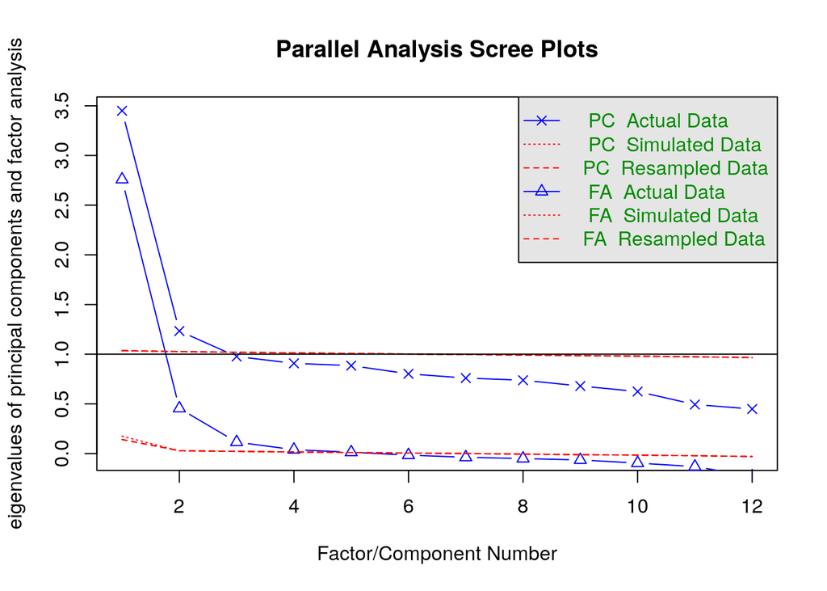

```
## Parallel analysis suggests that the number of factors =  4  and the number of components =  2
```

```r
#0
fa.parallel(train_0)
```

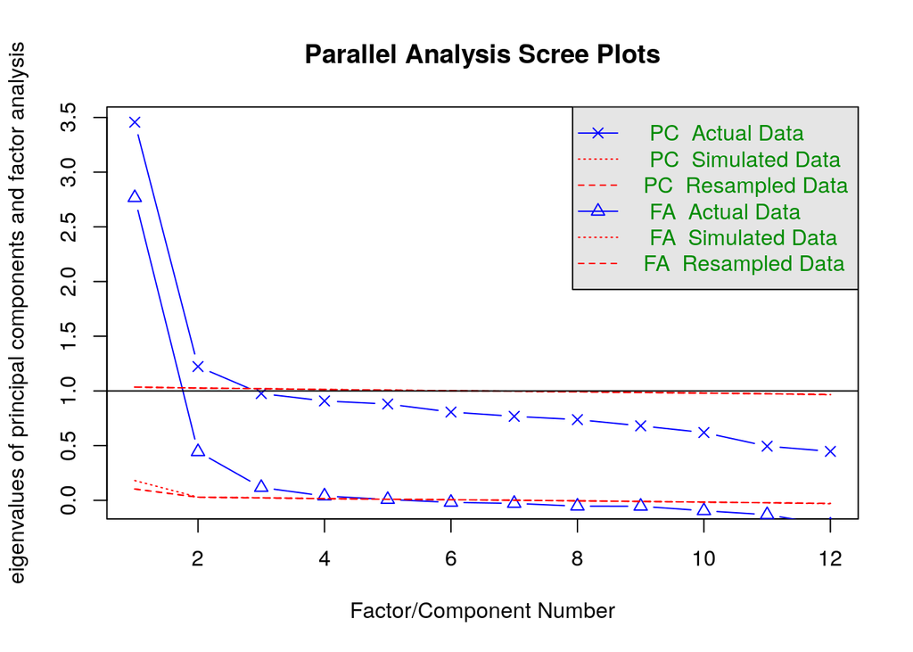

```
## Parallel analysis suggests that the number of factors =  4  and the number of components =  2
```

```r
#1
fa.parallel(train_1)
```

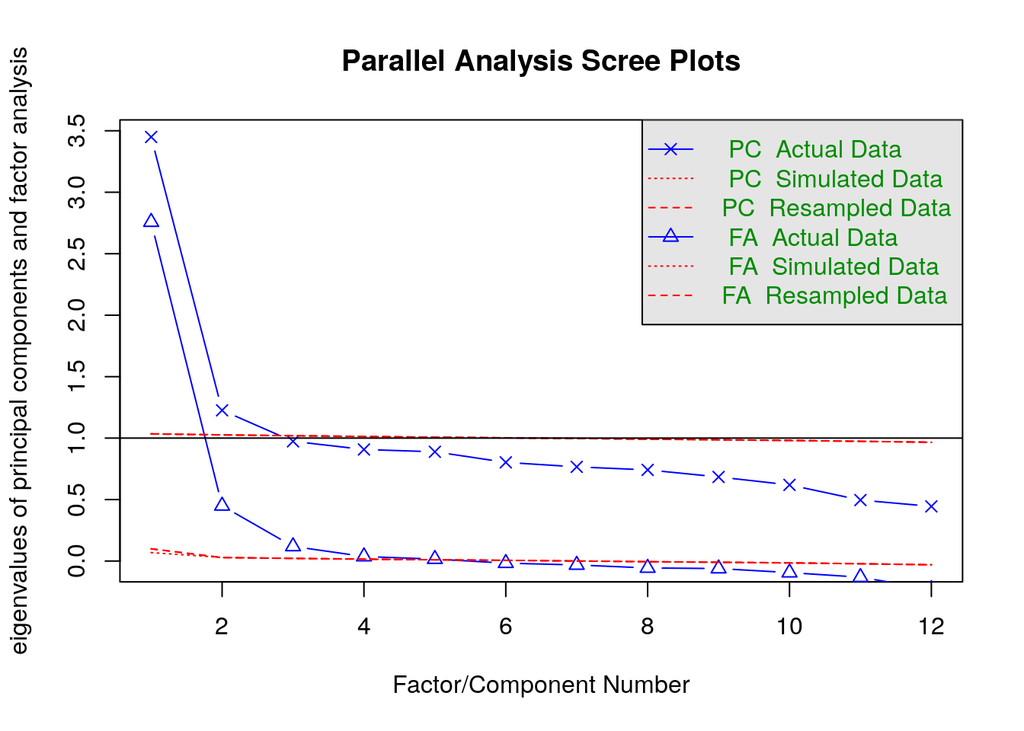

```
## Parallel analysis suggests that the number of factors =  5  and the number of components =  2
```

```r
#2
fa.parallel(train_2)
```

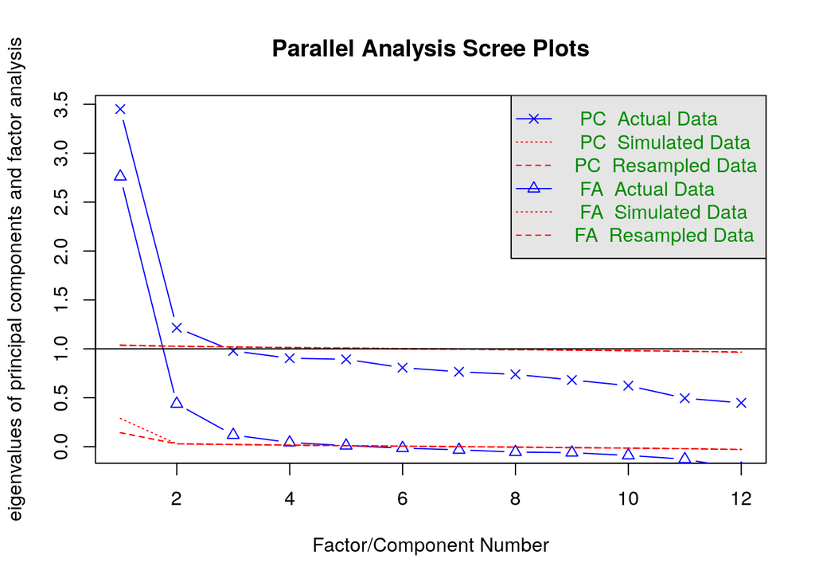

```
## Parallel analysis suggests that the number of factors =  4  and the number of components =  2
```

```r
#3
fa.parallel(train_3)
```

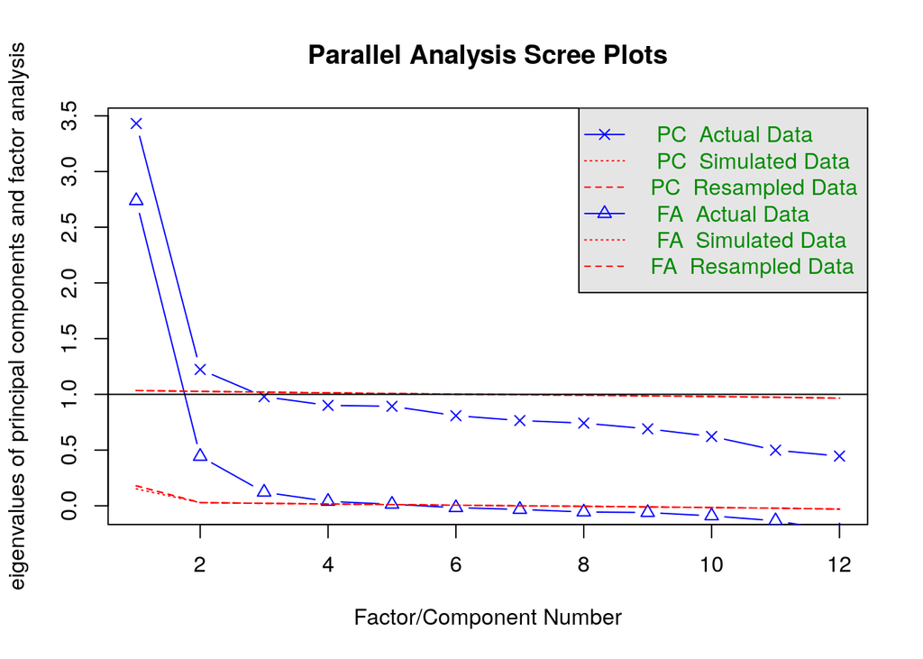

```
## Parallel analysis suggests that the number of factors =  5  and the number of components =  2
```

```r
#4
fa.parallel(train_4)
```

Fit EFA

```r
#0
efa_0 <- esem_efa(train_0, nfactors = 4)
loadings_0 <- efa_0$loadings
#1
efa_1 <- esem_efa(train_1, nfactors = 4)
loadings_1 <- efa_1$loadings
#2
efa_2 <- esem_efa(train_2, nfactors = 4)
loadings_2 <- efa_2$loadings
#3
efa_3 <- esem_efa(train_3, nfactors = 4)
loadings_3 <- efa_3$loadings
#4
efa_4 <- esem_efa(train_4, nfactors = 4)
loadings_4 <- efa_4$loadings
```

```r
# Export each group's loadings
for (i in 0:4) {
  efa_name <- paste0("efa_", i)
  loadings_name <- paste0("loadings_", i)

  # Get the object
  efa_obj <- get(efa_name)

  # Extract loadings
  loadings_df <- as.data.frame(unclass(efa_obj$loadings))
  loadings_df <- round(loadings_df, 3)
  loadings_df$Variable <- rownames(loadings_df)

  # Save to CSV
  #write.csv(
    #loadings_df,
    #file = paste0("efa_loadings/", loadings_name, ".csv"),
    #row.names = FALSE)

  # Print to console
  cat("\nFactor Loadings for Group", i, "\n")
  print(loadings_df)
}
```

```
##
## Factor Loadings for Group 0
##                                                             PA2    PA1    PA3
## Numeric.memory..Maximum.digits.remembered.correctly       0.378 -0.111  0.060
## Prospective.memory..Initial.answer                       -0.051  0.000  0.435
## Matrix.pattern.completion..Number.of.puzzles.correct      0.195 -0.028  0.452
## Fluid.intelligence.score                                  0.724 -0.058  0.032
## PAL..Number.of.correct.pairs                              0.048 -0.028  0.451
## Tower.rearranging..Number.of.puzzles.correct              0.123 -0.107  0.346
## Picture.vocabulary..Specific.cognitive.ability            0.572  0.049 -0.014
## Symbol.digit.substitution..Proportion.of.correct.matches -0.007  0.124  0.332
## X.log.TMT..Duration.to.complete.numeric.path              0.002  0.688  0.026
## X.log.TMT..Duration.to.complete.alphabetic.path          -0.203  0.596 -0.058
## X.log.Reaction.time                                       0.052  0.419 -0.036
## X.logx.1.Pairs.matching..Incorrect.matches                0.031  0.109 -0.239
##                                                             PA4
## Numeric.memory..Maximum.digits.remembered.correctly      -0.037
## Prospective.memory..Initial.answer                        0.123
## Matrix.pattern.completion..Number.of.puzzles.correct     -0.005
## Fluid.intelligence.score                                  0.013
## PAL..Number.of.correct.pairs                              0.238
## Tower.rearranging..Number.of.puzzles.correct             -0.130
## Picture.vocabulary..Specific.cognitive.ability            0.297
## Symbol.digit.substitution..Proportion.of.correct.matches -0.091
## X.log.TMT..Duration.to.complete.numeric.path             -0.005
## X.log.TMT..Duration.to.complete.alphabetic.path           0.045
## X.log.Reaction.time                                      -0.058
## X.logx.1.Pairs.matching..Incorrect.matches                0.081
##                                                                                                          Variable
## Numeric.memory..Maximum.digits.remembered.correctly           Numeric.memory..Maximum.digits.remembered.correctly
## Prospective.memory..Initial.answer                                             Prospective.memory..Initial.answer
## Matrix.pattern.completion..Number.of.puzzles.correct         Matrix.pattern.completion..Number.of.puzzles.correct
## Fluid.intelligence.score                                                                 Fluid.intelligence.score
## PAL..Number.of.correct.pairs                                                         PAL..Number.of.correct.pairs
## Tower.rearranging..Number.of.puzzles.correct                         Tower.rearranging..Number.of.puzzles.correct
## Picture.vocabulary..Specific.cognitive.ability                     Picture.vocabulary..Specific.cognitive.ability
## Symbol.digit.substitution..Proportion.of.correct.matches Symbol.digit.substitution..Proportion.of.correct.matches
## X.log.TMT..Duration.to.complete.numeric.path                         X.log.TMT..Duration.to.complete.numeric.path
## X.log.TMT..Duration.to.complete.alphabetic.path                   X.log.TMT..Duration.to.complete.alphabetic.path
## X.log.Reaction.time                                                                           X.log.Reaction.time
```

[output cut: 150 more lines]

```
## X.log.Reaction.time                                      -0.033
## X.logx.1.Pairs.matching..Incorrect.matches                0.085
##                                                                                                          Variable
## Numeric.memory..Maximum.digits.remembered.correctly           Numeric.memory..Maximum.digits.remembered.correctly
## Prospective.memory..Initial.answer                                             Prospective.memory..Initial.answer
## Matrix.pattern.completion..Number.of.puzzles.correct         Matrix.pattern.completion..Number.of.puzzles.correct
## Fluid.intelligence.score                                                                 Fluid.intelligence.score
## PAL..Number.of.correct.pairs                                                         PAL..Number.of.correct.pairs
## Tower.rearranging..Number.of.puzzles.correct                         Tower.rearranging..Number.of.puzzles.correct
## Picture.vocabulary..Specific.cognitive.ability                     Picture.vocabulary..Specific.cognitive.ability
## Symbol.digit.substitution..Proportion.of.correct.matches Symbol.digit.substitution..Proportion.of.correct.matches
## X.log.TMT..Duration.to.complete.numeric.path                         X.log.TMT..Duration.to.complete.numeric.path
## X.log.TMT..Duration.to.complete.alphabetic.path                   X.log.TMT..Duration.to.complete.alphabetic.path
## X.log.Reaction.time                                                                           X.log.Reaction.time
## X.logx.1.Pairs.matching..Incorrect.matches                             X.logx.1.Pairs.matching..Incorrect.matches
```

Set new column names

```r
new_names <- c(Numeric.memory..Maximum.digits.remembered.correctly = "Numeric memory",
               Prospective.memory..Initial.answer = "Prospective memory: Initial answer",
               Matrix.pattern.completion..Number.of.puzzles.correct = "Matrix pattern completion: Number of puzzles correct",
               Fluid.intelligence.score = "Fluid intelligence score",
               PAL..Number.of.correct.pairs = "Paired associate learning: Number of correct pairs",
               Tower.rearranging..Number.of.puzzles.correct = "Tower rearranging: Number of puzzles correct",
               Picture.vocabulary..Specific.cognitive.ability  = "Picture vocabulary",
               Symbol.digit.substitution..Proportion.of.correct.matches =  "Symbol digit substitution: Proportion of correct matches",
               X.log.TMT..Duration.to.complete.numeric.path = "(log)Trail making test: Duration numeric",
               X.log.TMT..Duration.to.complete.alphabetic.path = "(log)Trail making test: Duration alphabetic",
               X.log.Reaction.time = "(log)Reaction time",
               X.logx.1.Pairs.matching..Incorrect.matches = "(logx+1)Pairs matching: Incorrect matches"
)
```

Create loading tables

```r
#0
esem_loadings_0 <- data.table(matrix(round(loadings_0, 3), nrow = 12, ncol = 4))
names(esem_loadings_0) <- c("F1","F2", "F3", "F4")
esem_loadings_0$item <- paste0(new_names)
esem_loadings_0 <- melt(esem_loadings_0, "item", variable.name = "latent")
#1
esem_loadings_1 <- data.table(matrix(round(loadings_1, 3), nrow = 12, ncol = 4))
names(esem_loadings_1) <- c("F1","F2", "F3", "F4")
esem_loadings_1$item <- paste0(new_names)
esem_loadings_1 <- melt(esem_loadings_1, "item", variable.name = "latent")
#2
esem_loadings_2 <- data.table(matrix(round(loadings_2, 3), nrow = 12, ncol = 4))
names(esem_loadings_2) <- c("F1","F2", "F3", "F4")
esem_loadings_2$item <- paste0(new_names)
esem_loadings_2 <- melt(esem_loadings_2, "item", variable.name = "latent")
#3
esem_loadings_3 <- data.table(matrix(round(loadings_3 , 3), nrow = 12, ncol = 4))
names(esem_loadings_3) <- c("F1","F2", "F3", "F4")
esem_loadings_3$item <- paste0(new_names)
esem_loadings_3 <- melt(esem_loadings_3, "item", variable.name = "latent")
#4
esem_loadings_4 <- data.table(matrix(round(loadings_4 , 3), nrow = 12, ncol = 4))
names(esem_loadings_4) <- c("F1","F2", "F3", "F4")
esem_loadings_4$item <- paste0(new_names)
esem_loadings_4 <- melt(esem_loadings_4, "item", variable.name = "latent")
```

Visualize factor loadings

```r
#0-4
indices <- 0:4
for (i in indices) {
  # Create a plot name
  plot_name <- paste0("loading_plot_", i)
  # Create a data name
  data_name <- paste0("esem_loadings_", i)
  # Assign the plot to the plot name using assign()
  assign(plot_name, ggplot(get(data_name), aes(x = item, y = value, fill = latent)) +
           geom_bar(stat = "identity") + coord_flip() + facet_wrap(~ latent, ncol = 1) +
  theme(legend.position = 'none', panel.grid.major = element_blank(), panel.grid.minor = element_blank(), panel.background = element_rect(fill = "white"),
        axis.title.y = element_text(vjust = 15),
        axis.title.x = element_text(vjust = -0.75, color = "black", size = 20),

        plot.title = element_text(color = "black", size = 25),
        plot.subtitle = element_text(color = "black", size = 40),

        axis.text.x = element_text(size = 12),
        axis.text.y = element_text(size = 8)) + scale_x_discrete(position = "top") +
        # Remove y axis name, change x axis title, and add main title
        ylab("Factor loading") + theme(axis.title.x = element_text(size = 10)) + xlab("") + ggtitle(paste0("Fold ", i)) + theme(plot.title = element_text(hjust = 0.5, size = 15)))
}
```

# Find referents and build the model

```r
#0
referents_0 <- find_referents(efa_0, factor_names = paste0("F",1:4))
model_syntax_0 <- syntax_composer(efa_0, referents_0, only_fix_crossloadings = FALSE)
g_model_0 <- paste(model_syntax_0,
                               "g =~ NA*F1 + F2 + F3 + F4 \n g ~~ 1*g \n", sep = "\n")
#1
referents_1 <- find_referents(efa_1, factor_names = paste0("F",1:4))
model_syntax_1 <- syntax_composer(efa_1, referents_1, only_fix_crossloadings = FALSE)
g_model_1 <- paste(model_syntax_1,
                               "g =~ NA*F1 + F2 + F3 + F4 \n g ~~ 1*g \n", sep = "\n")
#2
referents_2 <- find_referents(efa_2, factor_names = paste0("F",1:4))
model_syntax_2 <- syntax_composer(efa_2, referents_2, only_fix_crossloadings = FALSE)
g_model_2 <- paste(model_syntax_2,
                               "g =~ NA*F1 + F2 + F3 + F4 \n g ~~ 1*g \n", sep = "\n")
#3
referents_3 <- find_referents(efa_3, factor_names = paste0("F",1:4))
model_syntax_3 <- syntax_composer(efa_3, referents_3, only_fix_crossloadings = FALSE)
g_model_3 <- paste(model_syntax_3,
                               "g =~ NA*F1 + F2 + F3 + F4 \n g ~~ 1*g \n", sep = "\n")
#4
referents_4 <- find_referents(efa_4, factor_names = paste0("F",1:4))
model_syntax_4 <- syntax_composer(efa_4, referents_4, only_fix_crossloadings = FALSE)
g_model_4 <- paste(model_syntax_4,
                               "g =~ NA*F1 + F2 + F3 + F4 \n g ~~ 1*g \n", sep = "\n")
```

#Fit the model

- Brown, T. A. (2015). Confirmatory factor analysis for applied research (2nd Edition). New York, NY: Guilford Press. Hu, L., & Bentler, P. M. (1999). Cutoff criteria for fit indexes in covariance structure analysis: Conventional criteria versus new alternatives. Structural Equation Modeling, 6, 1-55.
- Kline, R. B. (2010). Principles and practice of structural equation modeling (3rd Edition). New York, NY: Guilford Press. Little, T. D. (2013). Longitudinal structural equation modeling. New York, NY: Guilford Press.

```r
#0
model_0_fit <- cfa(g_model_0, std.lv=T, data = train_0)
summary(model_0_fit, fit.measures = T, standardized = T)
```

```
## lavaan 0.6-19 ended normally after 46 iterations
##
##   Estimator                                         ML
##   Optimization method                           NLMINB
##   Number of model parameters                        48
##
##   Number of observations                         25517
##
## Model Test User Model:
##
##   Test statistic                               786.647
##   Degrees of freedom                                30
##   P-value (Chi-square)                           0.000
##
## Model Test Baseline Model:
##
##   Test statistic                             49933.804
##   Degrees of freedom                                66
##   P-value                                        0.000
##
## User Model versus Baseline Model:
##
##   Comparative Fit Index (CFI)                    0.985
##   Tucker-Lewis Index (TLI)                       0.967
##
## Loglikelihood and Information Criteria:
##
##   Loglikelihood user model (H0)            -409911.076
##   Loglikelihood unrestricted model (H1)    -409517.753
##
##   Akaike (AIC)                              819918.152
##   Bayesian (BIC)                            820309.212
##   Sample-size adjusted Bayesian (SABIC)     820156.670
##
## Root Mean Square Error of Approximation:
##
##   RMSEA                                          0.031
##   90 Percent confidence interval - lower         0.030
##   90 Percent confidence interval - upper         0.033
##   P-value H_0: RMSEA <= 0.050                    1.000
```

[output cut: 76 more lines]

```
##    .Prspctv.mm..I.    0.886    0.008  108.248    0.000    0.886    0.886
##    .Mtrx.pt...N...    0.452    0.010   44.082    0.000    0.452    0.454
##    .Fld.ntllgnc.sc    0.375    0.006   62.301    0.000    0.375    0.353
##    .PAL..Nmbr.f.c.    0.807    0.008  105.913    0.000    0.807    0.805
##    .Twr.rrrn..N...    0.701    0.008   92.191    0.000    0.701    0.700
##    .Pctr.vcbl..S..    0.583    0.007   81.428    0.000    0.583    0.560
##    .Symbl.d...P...    0.946    0.009  109.318    0.000    0.946    0.946
##    .X.l.TMT..D....    0.227    0.012   18.899    0.000    0.227    0.228
##    .X.l.TMT..D....    0.446    0.007   63.500    0.000    0.446    0.446
##    .X.log.Rectn.tm    0.859    0.008  104.955    0.000    0.859    0.859
##    .X.lgx.1.P...I.    0.884    0.009  103.680    0.000    0.884    0.884
##    .F1                1.000                               0.836    0.836
##    .F2                1.000                               0.592    0.592
##    .F3                1.000                               0.515    0.515
##    .F4                1.000                               1.000    1.000
```

```r
#1
model_1_fit <- cfa(g_model_1, std.lv=T, data = train_1)
summary(model_1_fit, fit.measures = T, standardized = T)
```

```
## lavaan 0.6-19 ended normally after 41 iterations
##
##   Estimator                                         ML
##   Optimization method                           NLMINB
##   Number of model parameters                        48
##
##   Number of observations                         25517
##
## Model Test User Model:
##
##   Test statistic                               857.397
##   Degrees of freedom                                30
##   P-value (Chi-square)                           0.000
##
## Model Test Baseline Model:
##
##   Test statistic                             50002.056
##   Degrees of freedom                                66
##   P-value                                        0.000
##
## User Model versus Baseline Model:
##
##   Comparative Fit Index (CFI)                    0.983
##   Tucker-Lewis Index (TLI)                       0.964
##
## Loglikelihood and Information Criteria:
##
##   Loglikelihood user model (H0)            -409912.325
##   Loglikelihood unrestricted model (H1)    -409483.626
##
##   Akaike (AIC)                              819920.650
##   Bayesian (BIC)                            820311.710
##   Sample-size adjusted Bayesian (SABIC)     820159.168
##
## Root Mean Square Error of Approximation:
##
##   RMSEA                                          0.033
##   90 Percent confidence interval - lower         0.031
##   90 Percent confidence interval - upper         0.035
##   P-value H_0: RMSEA <= 0.050                    1.000
```

[output cut: 76 more lines]

```
##    .Prspctv.mm..I.    0.871    0.008  105.830    0.000    0.871    0.871
##    .Mtrx.pt...N...    0.636    0.007   94.878    0.000    0.636    0.633
##    .Fld.ntllgnc.sc    0.365    0.006   57.874    0.000    0.365    0.337
##    .PAL..Nmbr.f.c.    0.498    0.011   44.370    0.000    0.498    0.500
##    .Twr.rrrn..N...    0.691    0.008   89.382    0.000    0.691    0.690
##    .Pctr.vcbl..S..    0.578    0.007   80.787    0.000    0.578    0.548
##    .Symbl.d...P...    0.943    0.009  107.788    0.000    0.943    0.943
##    .X.l.TMT..D....    0.325    0.011   30.175    0.000    0.325    0.325
##    .X.l.TMT..D....    0.453    0.006   76.011    0.000    0.453    0.454
##    .X.log.Rectn.tm    0.863    0.008  106.997    0.000    0.863    0.863
##    .X.lgx.1.P...I.    0.878    0.009  102.045    0.000    0.878    0.878
##    .F1                1.000                               0.799    0.799
##    .F2                1.000                               0.673    0.673
##    .F3                1.000                               0.500    0.500
##    .F4                1.000                               0.993    0.993
```

```r
#2
model_2_fit <- cfa(g_model_2, std.lv=T, data = train_2)
summary(model_2_fit, fit.measures = T, standardized = T)
```

```
## lavaan 0.6-19 ended normally after 44 iterations
##
##   Estimator                                         ML
##   Optimization method                           NLMINB
##   Number of model parameters                        48
##
##   Number of observations                         25518
##
## Model Test User Model:
##
##   Test statistic                               777.429
##   Degrees of freedom                                30
##   P-value (Chi-square)                           0.000
##
## Model Test Baseline Model:
##
##   Test statistic                             49890.069
##   Degrees of freedom                                66
##   P-value                                        0.000
##
## User Model versus Baseline Model:
##
##   Comparative Fit Index (CFI)                    0.985
##   Tucker-Lewis Index (TLI)                       0.967
##
## Loglikelihood and Information Criteria:
##
##   Loglikelihood user model (H0)            -409945.362
##   Loglikelihood unrestricted model (H1)    -409556.647
##
##   Akaike (AIC)                              819986.724
##   Bayesian (BIC)                            820377.787
##   Sample-size adjusted Bayesian (SABIC)     820225.244
##
## Root Mean Square Error of Approximation:
##
##   RMSEA                                          0.031
##   90 Percent confidence interval - lower         0.029
##   90 Percent confidence interval - upper         0.033
##   P-value H_0: RMSEA <= 0.050                    1.000
```

[output cut: 76 more lines]

```
##    .Prspctv.mm..I.    0.888    0.008  109.304    0.000    0.888    0.888
##    .Mtrx.pt...N...    0.389    0.011   34.365    0.000    0.389    0.391
##    .Fld.ntllgnc.sc    0.395    0.006   66.569    0.000    0.395    0.370
##    .PAL..Nmbr.f.c.    0.819    0.008  107.696    0.000    0.819    0.816
##    .Twr.rrrn..N...    0.702    0.008   91.524    0.000    0.702    0.701
##    .Pctr.vcbl..S..    0.563    0.007   78.729    0.000    0.563    0.536
##    .Symbl.d...P...    0.943    0.009  109.861    0.000    0.943    0.943
##    .X.l.TMT..D....    0.236    0.011   20.685    0.000    0.236    0.237
##    .X.l.TMT..D....    0.440    0.007   63.266    0.000    0.440    0.440
##    .X.log.Rectn.tm    0.861    0.008  105.204    0.000    0.861    0.861
##    .X.lgx.1.P...I.    0.883    0.009  103.482    0.000    0.883    0.883
##    .F1                1.000                               0.843    0.843
##    .F2                1.000                               0.607    0.607
##    .F3                1.000                               0.479    0.479
##    .F4                1.000                               1.000    1.000
```

```r
#3
model_3_fit <- cfa(g_model_3, std.lv=T, data = train_3)
summary(model_3_fit, fit.measures = T, standardized = T)
```

```
## lavaan 0.6-19 ended normally after 41 iterations
##
##   Estimator                                         ML
##   Optimization method                           NLMINB
##   Number of model parameters                        48
##
##   Number of observations                         25518
##
## Model Test User Model:
##
##   Test statistic                               875.326
##   Degrees of freedom                                30
##   P-value (Chi-square)                           0.000
##
## Model Test Baseline Model:
##
##   Test statistic                             49784.171
##   Degrees of freedom                                66
##   P-value                                        0.000
##
## User Model versus Baseline Model:
##
##   Comparative Fit Index (CFI)                    0.983
##   Tucker-Lewis Index (TLI)                       0.963
##
## Loglikelihood and Information Criteria:
##
##   Loglikelihood user model (H0)            -410047.259
##   Loglikelihood unrestricted model (H1)    -409609.596
##
##   Akaike (AIC)                              820190.518
##   Bayesian (BIC)                            820581.581
##   Sample-size adjusted Bayesian (SABIC)     820429.038
##
## Root Mean Square Error of Approximation:
##
##   RMSEA                                          0.033
##   90 Percent confidence interval - lower         0.031
##   90 Percent confidence interval - upper         0.035
##   P-value H_0: RMSEA <= 0.050                    1.000
```

[output cut: 76 more lines]

```
##    .Prspctv.mm..I.    0.873    0.008  105.524    0.000    0.873    0.873
##    .Mtrx.pt...N...    0.643    0.007   95.663    0.000    0.643    0.640
##    .Fld.ntllgnc.sc    0.372    0.006   59.140    0.000    0.372    0.345
##    .PAL..Nmbr.f.c.    0.523    0.010   51.596    0.000    0.523    0.526
##    .Twr.rrrn..N...    0.688    0.008   88.054    0.000    0.688    0.687
##    .Pctr.vcbl..S..    0.580    0.007   80.761    0.000    0.580    0.551
##    .Symbl.d...P...    0.948    0.009  109.207    0.000    0.948    0.948
##    .X.l.TMT..D....    0.294    0.012   25.157    0.000    0.294    0.294
##    .X.l.TMT..D....    0.452    0.006   74.461    0.000    0.452    0.452
##    .X.log.Rectn.tm    0.863    0.008  107.076    0.000    0.863    0.863
##    .X.lgx.1.P...I.    0.882    0.009  102.162    0.000    0.882    0.882
##    .F1                1.000                               0.808    0.808
##    .F2                1.000                               0.637    0.637
##    .F3                1.000                               0.540    0.540
##    .F4                1.000                               0.991    0.991
```

```r
#4
model_4_fit <- cfa(g_model_4, std.lv=T, data = train_4)
summary(model_4_fit, fit.measures = T, standardized = T)
```

```
## lavaan 0.6-19 ended normally after 44 iterations
##
##   Estimator                                         ML
##   Optimization method                           NLMINB
##   Number of model parameters                        48
##
##   Number of observations                         25518
##
## Model Test User Model:
##
##   Test statistic                               798.028
##   Degrees of freedom                                30
##   P-value (Chi-square)                           0.000
##
## Model Test Baseline Model:
##
##   Test statistic                             49288.256
##   Degrees of freedom                                66
##   P-value                                        0.000
##
## User Model versus Baseline Model:
##
##   Comparative Fit Index (CFI)                    0.984
##   Tucker-Lewis Index (TLI)                       0.966
##
## Loglikelihood and Information Criteria:
##
##   Loglikelihood user model (H0)            -410256.568
##   Loglikelihood unrestricted model (H1)    -409857.554
##
##   Akaike (AIC)                              820609.135
##   Bayesian (BIC)                            821000.198
##   Sample-size adjusted Bayesian (SABIC)     820847.655
##
## Root Mean Square Error of Approximation:
##
##   RMSEA                                          0.032
##   90 Percent confidence interval - lower         0.030
##   90 Percent confidence interval - upper         0.034
##   P-value H_0: RMSEA <= 0.050                    1.000
```

[output cut: 76 more lines]

```
##    .Prspctv.mm..I.    0.887    0.008  109.078    0.000    0.887    0.886
##    .Mtrx.pt...N...    0.397    0.011   36.179    0.000    0.397    0.398
##    .Fld.ntllgnc.sc    0.372    0.006   61.839    0.000    0.372    0.349
##    .PAL..Nmbr.f.c.    0.816    0.008  107.514    0.000    0.816    0.813
##    .Twr.rrrn..N...    0.702    0.008   91.129    0.000    0.702    0.701
##    .Pctr.vcbl..S..    0.590    0.007   82.191    0.000    0.590    0.567
##    .Symbl.d...P...    0.944    0.009  109.786    0.000    0.944    0.944
##    .X.l.TMT..D....    0.220    0.012   18.656    0.000    0.220    0.221
##    .X.l.TMT..D....    0.450    0.007   65.085    0.000    0.450    0.450
##    .X.log.Rectn.tm    0.864    0.008  104.699    0.000    0.864    0.865
##    .X.lgx.1.P...I.    0.888    0.009  103.391    0.000    0.888    0.888
##    .F1                1.000                               0.838    0.838
##    .F2                1.000                               0.595    0.595
##    .F3                1.000                               0.493    0.493
##    .F4                1.000                               0.995    0.995
```